# Discussion 4

# Present Group Members

Please **write the names of your group members** here.

> Present Group Member(s):

> Absent Group Member(s):

# Preliminaries

- This file should be in `STAT240/discussion/ds04`.
- You should also download `exoplanets-clean-through-2022.csv` to `STAT240/data`.
- You will need the `scales` package for this assignment; install it with `install.packages("scales")`.
- This assignment should be completed in your **assigned Canvas groups**. Only one person has to submit on behalf of the group. You may submit whatever you have at the end of discussion section for full credit.

# Problem 1

```r
planets = read_csv("../../data/exoplanets-clean-through-2022.csv")
```

**Astronomical background**: As time goes on, our ability to find small planets has gotten better.

Starting from `planets`,

- **Drop** all the planets whose `radius` is missing.
- **Grouping by year**, `summarize()` to determine the minimum `radius` of planets discovered in each year.
- **Save** this dataframe as `smallest_planets`.

```r
smallest_planets = planets %>%
  drop_na(radius) %>%
  group_by(year) %>%
  summarize(smallest_radius = min(radius))
```

# Problem 2

Using `smallest_planets` from the previous problem,

Create a **scatter plot** of points, with `year` on the x axis and the smallest radius of a planet discovered in that year on the y axis.

Add a **smooth trend line** through the data. You decide whether or not it is appropriate to constrain the line to be straight.

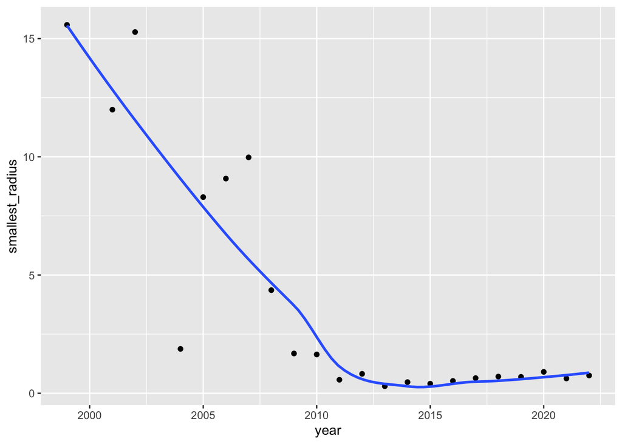

```r
ggplot(smallest_planets, aes(year, smallest_radius)) +
  geom_point() +
  geom_smooth(se = F)
```

Does your graph support the idea that we are getting better at finding smaller planets over time?

> Yes; up to a point. There seems to be a “floor” on how small the planets we find can be, that we hit around 2015.

# Problem 3

**Astronomical background**: When using the Transit method to detect exoplanets, we usually get enough information to also estimate their radius, but not their mass.

Starting from `planets`, and using **only planets discovered using the Transit method**, `summarize` to determine:

- The total number of planets discovered using the Transit method,
- How many of those planets have missing data for `radius`
- How many of those planets have missing data for `mass`

*Hint: `is.na(radius)` will return a long vector of `TRUE`s and `FALSE`s… how do we convert that into a single number, the count of `TRUE`s?*

```r
planets %>%
  filter(method == "Transit") %>%
  summarize(total = n(),
            radMissing = sum(is.na(radius)),
            massMissing = sum(is.na(mass)))
```

```
## # A tibble: 1 × 3
##   total radMissing massMissing
##   <int>      <int>       <int>
## 1  3939         22        2956
```

*Your answer should be a one row, three column dataframe with descriptive column names.*

# Problem 4

In the previous problem, using only Transit planets, we counted # of planets, # of planets with missing mass, and # of planets with missing radii.

**Using `group_by`**, do the same calculation as the previous problem, but this time for all `method`s at once. You should end up with one row for every `method`, and four columns; `method`, plus the three summary features.

**Save** this dataframe as `missing_by_method`.

```r
missing_by_method = planets %>%
  group_by(method) %>%
  summarize(total = n(),
            radMissing = sum(is.na(radius)),
            massMissing = sum(is.na(mass)))
```

# Problem 5

Using `missing_by_method` from the previous problem,

- **Filter** to only include methods which have discovered at least 50 planets.
- **Create a new column called `r_miss_perc`** representing the **percentage** of planets discovered by that method whose radius is missing/unknown.
- **Keep** only three columns, `method`, the total number of planets, and `r_miss_perc`.
- **Save** this dataframe as `radius_missing_percentages`.

```r
radius_missing_percentages = missing_by_method %>%
  filter(total > 50) %>%
  mutate(r_miss_perc = radMissing/total) %>%
  select(method, total, r_miss_perc)
```

# Problem 6

The following two problems will expose us to more ggplot customization features.

Using `radius_missing_percentages`, create a **bar plot** (using either `geom_bar()` or `geom_col()`, left to you to figure out) which plots `r_miss_perc` for each `method`.

Incorporate the following customizations:

- `fill` the columns according to total number of planets discovered.
- Whatever axis you put the percentage on, use the appropriate `scale_*_*` command with the argument `labels = label_percent()`.
  - Previously, we had only seen `labels = some vector of custom labels`. `labels` also accepts functions like `label_percent()` which will transform your old labels (such as 0.25) to better looking ones (such as 25%).

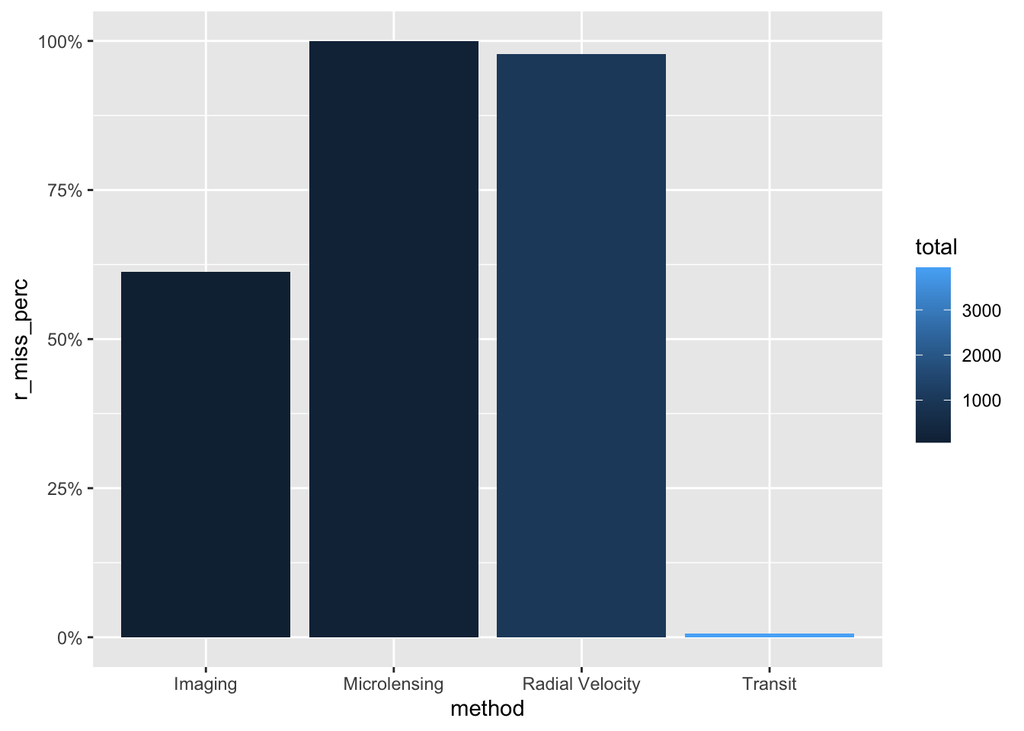

```r
ggplot(radius_missing_percentages, aes(method, r_miss_perc, fill = total)) +
  geom_col() +
  scale_y_continuous(labels = label_percent())
```

# Problem 7

In this problem, we make two further improvements to the previous plot. Please **copy and paste** your code from the previous problem into the chunk below and modify it.

First, notice that `method`, by default, plots in alphabetical order. What if we wanted to instead arrange the methods such that the bars were of increasing height? We can accomplish this with `reorder(x, y)`; where `x` is the column to reorder, and `y` is the secondary column whose values will dictate the new order of `x`.

**Replace** `method` in your graphing code with `reorder(method, r_miss_perc)`.

Notice how the bar order has changed.

Second, notice that the color scheme by default is not super helpful in distinguishing between the three non-Transit methods. It would help if our color scale was not linear, but exponential, to account for Transit being a high outlier.

**Add the following layer** to your graph: `scale_fill_gradient(trans = "log10")`.

Notice how the legend labeling has changed.

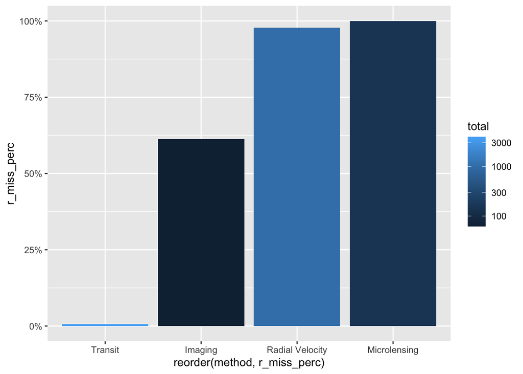

```r
ggplot(radius_missing_percentages, aes(reorder(method, r_miss_perc), r_miss_perc, fill = total)) +
  geom_col() +
  scale_y_continuous(labels = label_percent()) +
  scale_fill_gradient(trans = "log10")
```